# Temperatura histórica en C.A.B.A.

Laboratorio de Datos

Ariel Salgado

20 de Julio de 2021

# Este notebook

En este notebook el objetivo es que ustedes puedan emplear lo visto en el notebook *Nociones básicas de estadística descriptiva* para caracterizar la evolución de la temperatura mensual en la C.A.B.A.

Proponemos una serie de preguntas *guía* a responder usando las herramientas que vimos en el notebook de estadística descriptiva. Sientan la libertad de hacer nuevas preguntas y explorar el dataset libremente.

# El dataset

El dataset que usaremos puede descargarse (además del repositorio) de la página del gobierno de la ciudad en formato csv: https://data.buenosaires.gob.ar/dataset/registro-temperatura-ciudad

Carguemoslo:

```r
datos = read.csv('historico_temperaturas.csv')
```

- Visualicen las primeras filas usando la función `head`

```r
head(datos)
```

|  | año | mes | máxima | mínima | media |
| --- | --- | --- | --- | --- | --- |
| 1 | 1991 | Enero | 28.4 | 19.8 | 24.10 |
| 2 | 1991 | Febrero | 27.8 | 17.8 | 22.80 |
| 3 | 1991 | Marzo | 27.6 | 18.4 | 23.00 |
| 4 | 1991 | Abril | 22.4 | 13.6 | 18.00 |
| 5 | 1991 | Mayo | 20.7 | 12.2 | 16.45 |
| 6 | 1991 | Junio | 14.8 | 7.6 | 11.20 |

Dado que mes y año no están en un formato cómodo para ser procesado y graficado, necesitamos crear un string que contenga esa misma información pero en formato *YYYY-MM-DD* (año-mes-día). Hay formas de hacerlo automáticamente, pero hoy la función la van a hacer ustedes. Les dejo un boceto:

```r
arma_fecha = function(año,mes){
  # Primero necesitamos convertir el mes en palabras a número con dos dígitos.
  # Lo hacemos con un diccionario y la función match
  diccionario = c('Enero'='01',
                   'Febrero'='02',
                   'Marzo'='03',
                   'Abril'='04',
                   'Mayo'='05',
                   'Junio'='06',
                   'Julio'='07',
                   'Agosto'='08',
                   'Septiembre'='09',
                   'Octubre'='10',
                   'Noviembre'='11',
                   'Diciembre'='12')
  mes_numerico = diccionario[match(mes,names(diccionario))] # Exploren esto un poco en la consola para ver qué hace exactamente.
  fechas = paste(año,mes_numerico,'01',sep='-')
  # Fijamos el día siempre en el primero del més
  fechas = as.Date(fechas) # Lo convertimos a un formato de fecha
  return(fechas)
}

datos$fecha = arma_fecha(datos$año,datos$mes)
```

# Preguntas

#### ¿Qué puede decir de la evolución de la temperatura a lo largo del tiempo?

Realice un gráfico que muestre la temperatura media en función de la fecha. *Sugerencia: agregando en* `plot(x,y)` *la opción `type='l'` obtenemos un gráfico de lineas:* `plot(x,y,type='l')`.

- Respuesta:

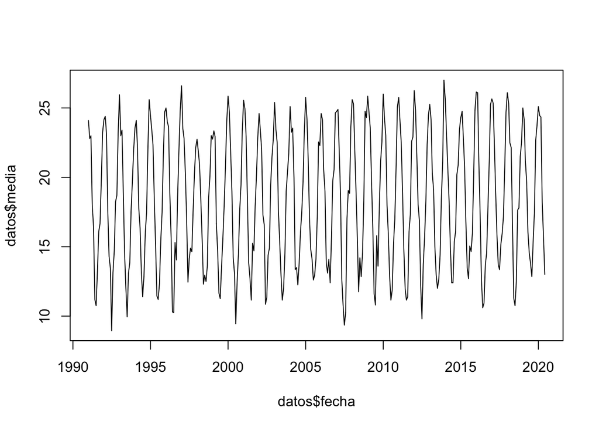

```r
plot(datos$fecha,datos$media,type='l')
```

#### ¿Qué puede decir de la evolución de la mínima y la máxima en función del tiempo?

Realice un gráfico que muestre la evolución de las tres temperaturas (mínima, media y máxima) a la vez, con lineas y usando diferentes colores. *Los colores los indicamos usando la opción* `col` _ en la función `plot`. _Para agregar lineas usamos la función `lines`.

- Respuesta:

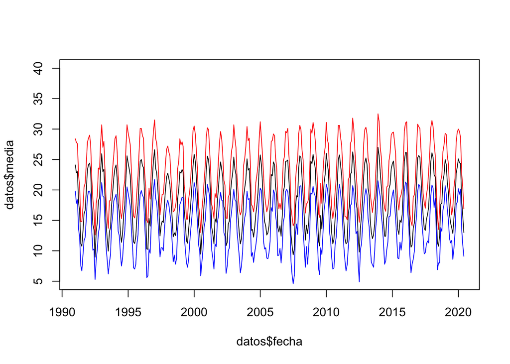

```r
plot(datos$fecha,datos$media,type='l',ylim=c(5,40))
lines(datos$fecha,datos$máxima,col='red')
lines(datos$fecha,datos$mínima,col='blue')
```

#### ¿En qué año y mes se registró la temperatura máxima? ¿Y la mínima?

Detecte, año, mes y fecha y repita el gráfico anterior, agregando un punto rojo y uno azul en la posición de la temperatura máxima y mínima. *Para agregar puntos a un gráfico, puede usar la función* `points` *, similar a* `lines` *. Para ubicar las posiciones donde ocurre el máximo y el mínimo de un vector aproveche las funciones* `which.max` *y* `which.min`.

- Respuesta

```r
imax = which.max(datos$máxima)
imin = which.min(datos$mínima)

print(datos[imax,])
```

```
##      año       mes máxima mínima media      fecha
## 276 2013 Diciembre   32.5   21.5    27 2013-12-01
```

```r
print(datos[imin,])
```

```
##      año   mes máxima mínima media      fecha
## 199 2007 Julio   14.1    4.6  9.35 2007-07-01
```

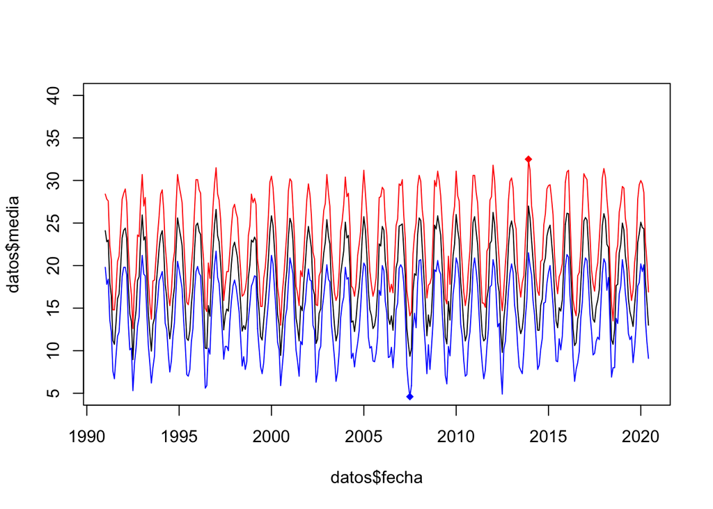

```r
plot(datos$fecha,datos$media,type='l',ylim=c(5,40))
lines(datos$fecha,datos$máxima,col='red')
lines(datos$fecha,datos$mínima,col='blue')
points(datos$fecha[imax],datos$máxima[imax],col='red',pch=18)
points(datos$fecha[imin],datos$mínima[imin],col='blue',pch=18)
```

#### ¿En torno a que valor ronda la temperatura en C.A.B.A.?

Calcule las temperaturas promedio y mediana a lo largo de todos los años usando la temperatura media mensual. ¿Son similares en este caso? Calcule la desviación estandar de la temperatura media y los cuartiles 1ro y 3ro, y agreguelos al gráfico original de la temperatura media. *La función* `abline` *permite dibujar lineas horizontales a través de su argumento* `h`.

```r
promedio = mean(datos$media)
mediana = median(datos$media)
SD = sd(datos$media)
Q1 = quantile(datos$media,.25)
Q3 = quantile(datos$media,.75)
print(promedio)
```

```
## [1] 18.40493
```

```r
print(mediana)
```

```
## [1] 18.275
```

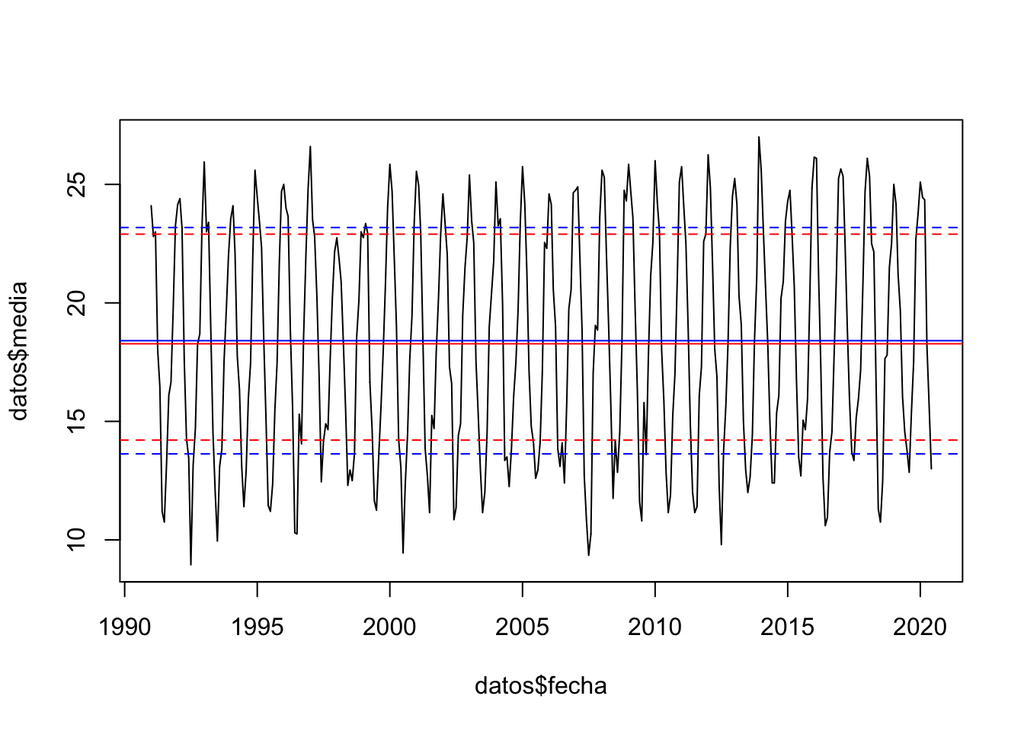

```r
plot(datos$fecha,datos$media,type='l')
abline(h=promedio,col='blue',lty='solid')
abline(h=mediana,col='red',lty='solid')
abline(h=promedio+c(-SD,SD),col='blue',lty='dashed')
abline(h=c(Q1,Q3),col='red',lty='dashed')
```

#### ¿Cuál es el mes más frio del año? ¿Y el más cálido?

Calcule la temperatura media, mínima y máxima promedio para cada mes, y construya un boxplot de la temperatura media separado por mes. ¿Qué meses presentan temperaturas más atípicas?

```r
medias_mensuales = rep(NA,12) # Un vector a completar con la temperatura media de cada mes
minimas_mensuales = rep(NA,12)
maximas_mensuales = rep(NA,12)
meses = unique(datos$mes)


for(i in 1:length(meses)){
  mes = meses[i]
  medias_mensuales[i] = mean(datos$media[datos$mes==mes])
  minimas_mensuales[i] = mean(datos$mínima[datos$mes==mes])
  maximas_mensuales[i] = mean(datos$máxima[datos$mes==mes])
}

temperaturas_mensuales = cbind(medias_mensuales,minimas_mensuales,maximas_mensuales)
rownames(temperaturas_mensuales) = meses

print(temperaturas_mensuales)
```

```
##            medias_mensuales minimas_mensuales maximas_mensuales
## Enero              25.11667         20.200000          30.03333
## Febrero            24.11833         19.350000          28.88667
## Marzo              22.32833         17.720000          26.93667
## Abril              18.65833         14.066667          23.25000
## Mayo               15.26333         11.096667          19.43000
## Junio              12.38000          8.373333          16.38667
## Julio              11.56207          7.641379          15.48276
## Agosto             13.35672          8.868966          17.84483
## Septiembre         15.15172         10.641379          19.66207
## Octubre            17.96552         13.375862          22.55517
## Noviembre          20.96897         16.037931          25.90000
## Diciembre          23.73276         18.600000          28.86552
```

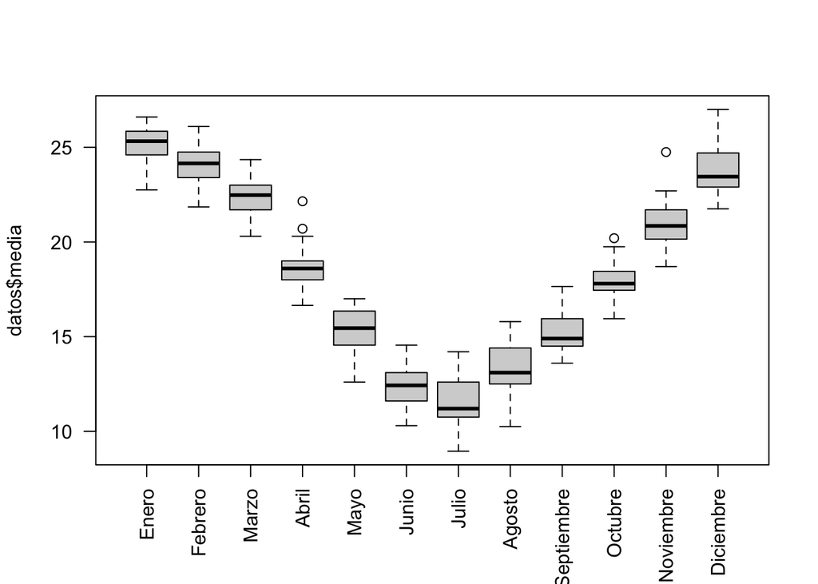

```r
datos$mes = factor(datos$mes,meses)
boxplot(datos$media~datos$mes,las=2,xlab='')
```

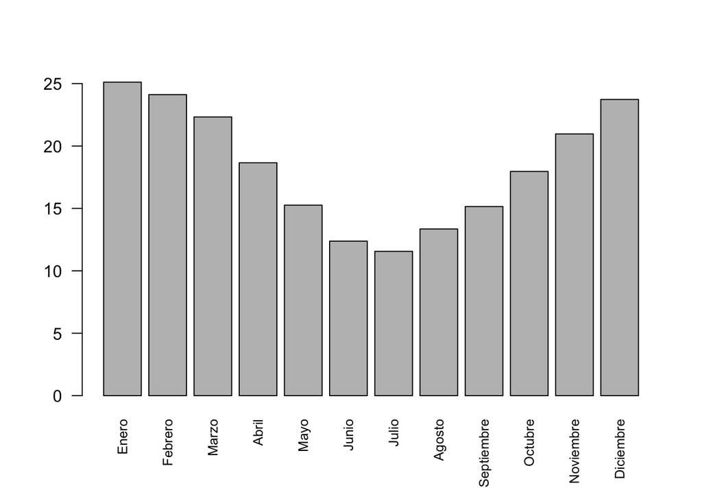

```r
# Acá el barplot también
barplot(medias_mensuales,names.arg = meses,las=2,cex.names=.8)
```

#### ¿Cuál es el mes con temperatura más variable?

Calcule la variabilidad de cada mes como `máxima-mínima` y calcule el promedio mensual y construya un boxplot para cada mes. ¿En qué mes es más variable la temperatura? ¿Y en cuál menos? ¿Observa una relación con la temperatura del mes?

```r
datos$variabilidad = datos$máxima-datos$mínima
variabilidad_mensual = rep(NA,12) # Un vector a
for(i in 1:length(meses)){
  mes = meses[i]
  variabilidad_mensual[i] = mean(datos$variabilidad[datos$mes==mes])
}
names(variabilidad_mensual) = meses
print(variabilidad_mensual)
```

```
##      Enero    Febrero      Marzo      Abril       Mayo      Junio      Julio
##   9.833333   9.536667   9.216667   9.183333   8.333333   8.013333   7.841379
##     Agosto Septiembre    Octubre  Noviembre  Diciembre
##   8.975862   9.020690   9.179310   9.862069  10.265517
```

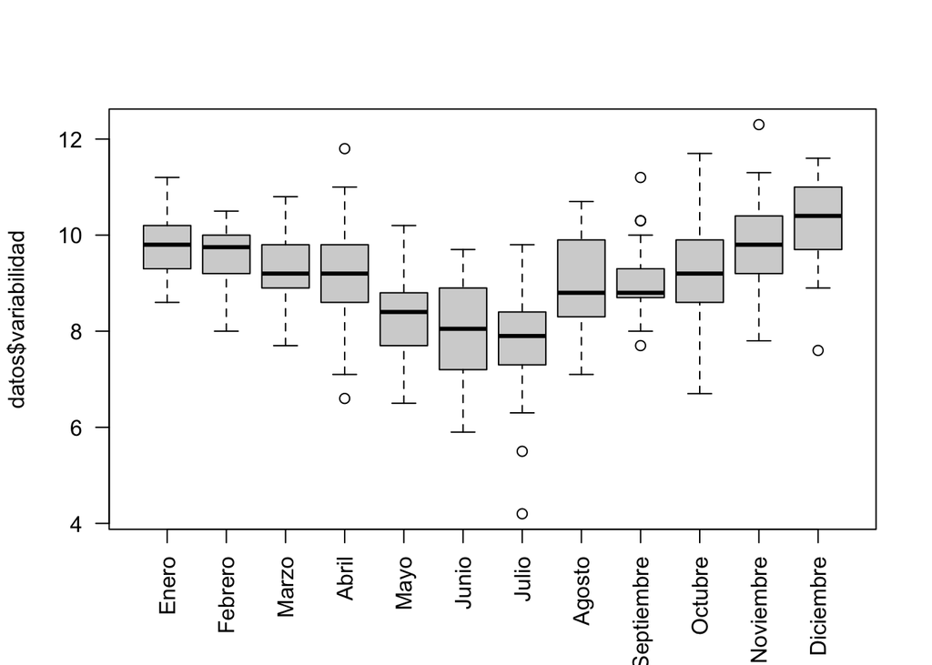

```r
boxplot(datos$variabilidad~datos$mes,las=2,xlab='')
```

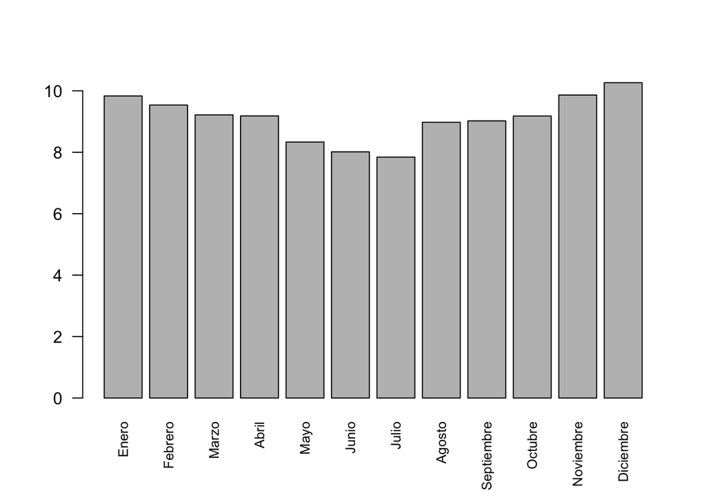

```r
barplot(variabilidad_mensual,names.arg = meses,las=2,cex.names=.8)
barplot(variabilidad_mensual,names.arg = meses,las=2,cex.names=.8)
```

#### ¿Cómo se relacionan la temperatura media y la variabilidad?

Grafique la temperatura media contra la variabilidad. ¿Observa una relación? Calcule el coeficiente de correlación entre ambas. ¿Se condice con lo que observa en el gráfico?

```r
colores = as.numeric((datos$fecha-min(datos$fecha)))/(as.numeric(diff(range(datos$fecha))))
colores = rgb(1-colores,colores,0)
plot(datos$media,datos$variabilidad,col=colores,pch=18)
print(cor(datos$media,datos$variabilidad))
```

```
## [1] 0.5236947
```

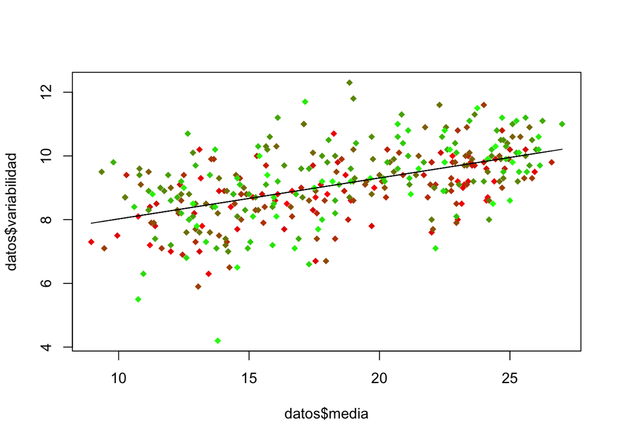

```r
md = lm(variabilidad~media,data = datos)
lines(datos$media,predict(md))
```

#### ¿Cómo cambió la temperatura a lo largo de los años?

Grafique boxplots separando la temperatura media por año, y la variabilidad por año. Calcule la temperatura media, mínima y máxima por año. ¿Detecta algún año especialmente frío? Grafique la temperatura media máxima y mínima año a año. Calcule la correlación entre el año y la temperatura media.

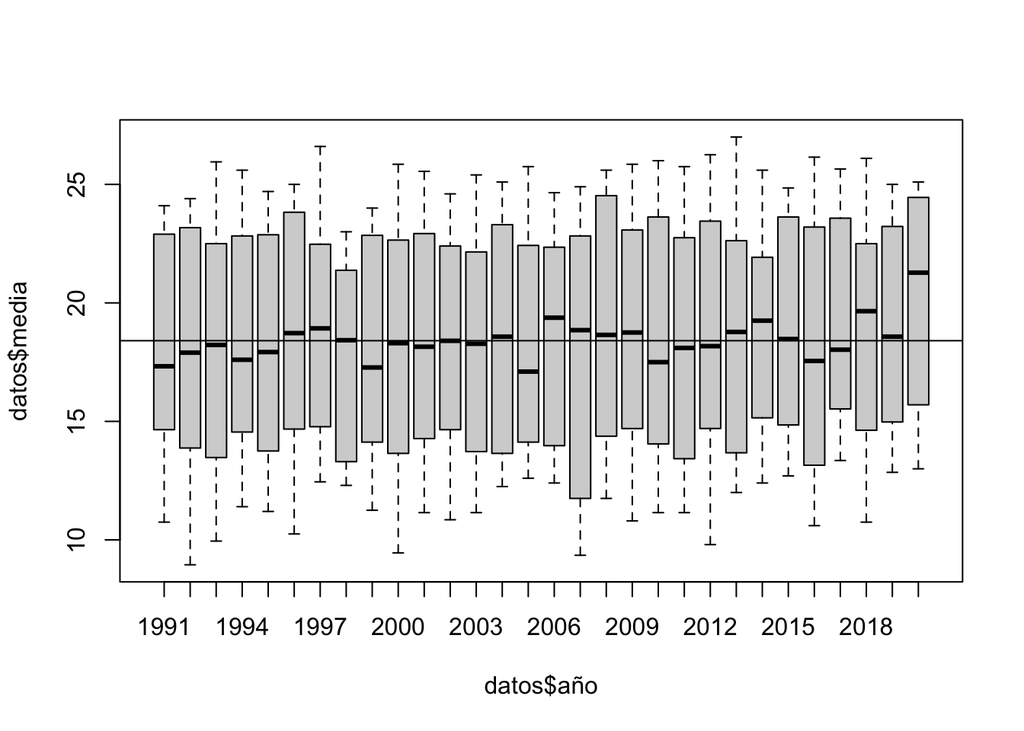

```r
boxplot(datos$media~datos$año)
abline(h=mean(datos$media))
```

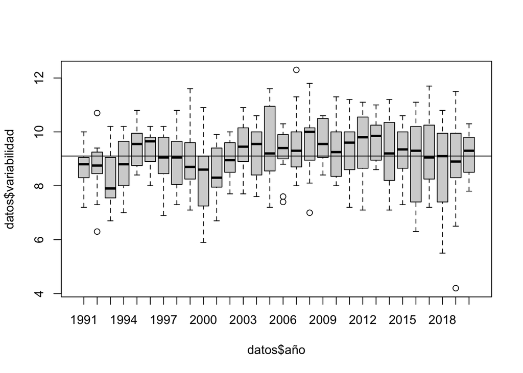

```r
boxplot(datos$variabilidad~datos$año)
abline(h=mean(datos$variabilidad))
```

```r
años = unique(datos$año)

medias_anual = rep(NA,length(años))
minimas_anual = rep(NA,length(años))
maximas_anual = rep(NA,length(años))
for(i in 1:length(años)){
  año = años[i]
  medias_anual[i] = mean(datos$media[datos$año==año])
  minimas_anual[i] = mean(datos$mínima[datos$año==año])
  maximas_anual[i] = mean(datos$máxima[datos$año==año])
}

temperaturas_anuales = cbind(medias_anual,minimas_anual,maximas_anual)
rownames(temperaturas_anuales) = años

años_fecha = as.Date(as.character(años),format='%Y')
print(temperaturas_anuales)
```

```
##      medias_anual minimas_anual maximas_anual
## 1991     17.94167      13.60833      22.27500
## 1992     17.82917      13.48333      22.17500
## 1993     17.82917      13.71667      21.94167
## 1994     18.52500      14.15000      22.90000
## 1995     18.17500      13.45833      22.89167
## 1996     18.53750      13.84167      23.23333
## 1997     18.86250      14.40833      23.31667
## 1998     17.70000      13.24167      22.15833
## 1999     17.92500      13.45000      22.40000
## 2000     17.95833      13.79167      22.12500
## 2001     18.37500      14.11667      22.63333
## 2002     18.25833      13.77500      22.74167
## 2003     18.00417      13.28333      22.72500
## 2004     18.44583      13.81667      23.07500
```

[output cut: 16 more lines]

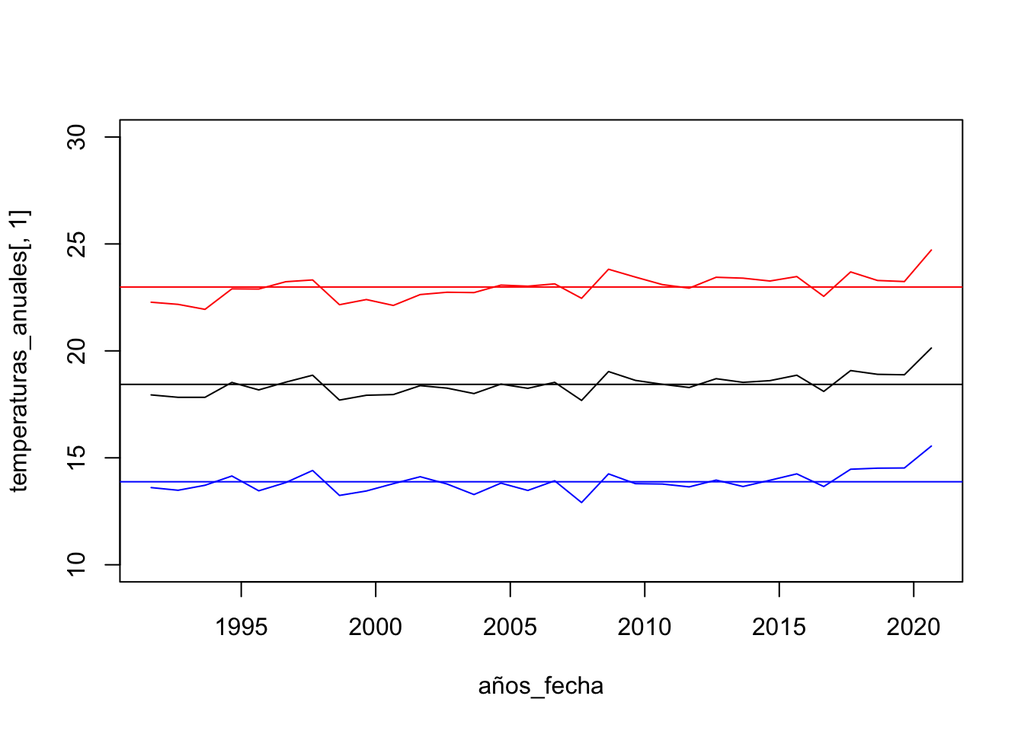

```r
plot(años_fecha,temperaturas_anuales[,1],type='l',ylim=c(10,30))
abline(h=mean(temperaturas_anuales[,1]))
lines(años_fecha,temperaturas_anuales[,2],col='blue')
abline(h=mean(temperaturas_anuales[,2]),col='blue')
lines(años_fecha,temperaturas_anuales[,3],col='red')
abline(h=mean(temperaturas_anuales[,3]),col='red')
```

```r
print(cor(años,temperaturas_anuales[,1]))
```

```
## [1] 0.6272737
```